# Week 23 Mini-Study: Why Streets Remember First

2026-06-05

## Proposition

The first public branch of the recombination question asks whether earlier movement in groups and activities helps predict later **physical** recombination.

This mini-study closes the week around that branch alone. It does not try to settle the still-open question of later activity recombination directly.

## What To Picture

Picture two tracts in the same metro area.

One begins the period with a fairly settled street pattern and only limited change in local users and activities. The other has more visible earlier motion in activity sectors and group context, but it also starts from a street fabric with more room to be reworked.

The proposition expects the second tract to show more later physical recombination. In the road data, connector and infill changes are the visible signs of that recombination-oriented shift.

## Why The Theory Expected This

TUEM treats urban evolution as a process of variation, selection, retention, and recombination across physical form, groups, and activities.

Physical form (**P**) is the inherited material setting: streets, parcels, buildings, and the spatial arrangement of urban life. Groups (**G**) are the residents, organizations, and populations that use a place. Activities (**A**) are the routines, services, establishments, institutions, and uses taking place there.

The broad intuition was sequential. Earlier movement in groups and activities should widen the set of possible later combinations. If that intuition held strongly in this branch, tracts with more earlier A/G motion would later show more recombination-oriented physical change.

## What Would Support Or Challenge The Claim

Support would look like positive earlier activity and group terms in within-metro sequence models. In ordinary language: tracts with more earlier activity-sector movement and more earlier group-context movement would later move more toward recombination-oriented physical change.

Challenge would look like weak A/G terms combined with a much stronger inherited-structure term. That would mean the broad lead story is too general for the physical branch and that inherited street fabric is doing more of the explanatory work.

## Data Used

The test uses a tract-level sequence-window dataset built to compare earlier social/activity movement with later street-network change. The unit is a tract-window. Models compare tracts within the same CBSA, so the comparison is tract against tract inside the same metropolitan setting.

Two high-coverage windows are used:

| Specification | Rows used | CBSAs | R-squared | Adjusted R-squared |
| --- | --- | --- | --- | --- |
| Long lead window | 1173 | 209 | 0.502 | 0.391 |
| NAICS-safe window | 2085 | 369 | 0.465 | 0.349 |

The long lead window uses earlier activity movement from 1995-2005, earlier group movement from 1980-2000, and later physical change from 2000-2015. The NAICS-safe window uses later activity and group lead windows to avoid the SIC/NAICS classification break.

## How The Concepts Become Measures

| Component | Plain meaning | Measure in this report | Status | Main limitation |
| --- | --- | --- | --- | --- |
| P | Later physical recombination | Recombination-oriented change in the road network | Direct physical branch proxy | Measures road-pattern recoding, not planning intent or social meaning |
| G | Earlier group-context movement | LTDB social-context movement before the later road-change window | Group proxy | Broad movement can hide the specific channels that matter |
| A | Earlier activity-context movement | ZBP activity-sector movement before the outcome window | Activity proxy | Too broad to observe fine-grained later activity recombination |
| Inherited P | Existing physical opportunity and constraint | Starting connector share and built maturity | Direct physical constraint proxy | Strong baseline effects can partly reflect ceiling effects |

## How To Read The Figure

Start with the gray points. They are the broad lead signals: earlier activity movement, earlier group movement, and their interaction. Points clearly to the right of zero would support the broad sequence claim. Intervals crossing zero mean the direction is too uncertain to carry the claim.

Then read the orange point. It is starting connector share, a measure of inherited street structure. Its position shows whether prior street-network form is doing more work than the earlier activity/group signals.

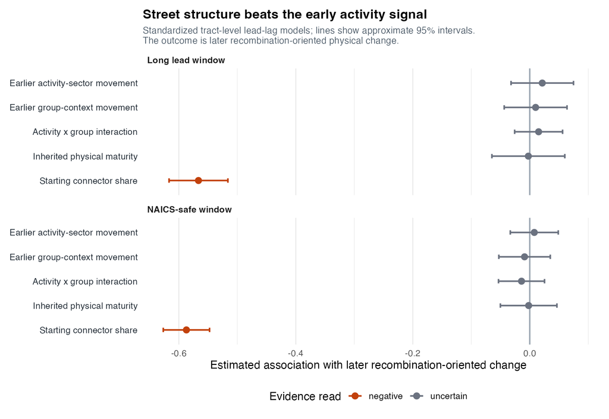

## Result

The broad lead story does not hold in this physical-recombination branch.

| Specification | Term | Estimate | Approx. 95% interval | p-value |
| --- | --- | --- | --- | --- |
| Long lead window | Earlier activity-sector movement | 0.021 | [-0.032, 0.075] | 0.433 |
| Long lead window | Earlier group-context movement | 0.010 | [-0.044, 0.064] | 0.715 |
| Long lead window | Starting connector share | -0.566 | [-0.617, -0.516] | <0.001 |
| Long lead window | Activity x group interaction | 0.015 | [-0.026, 0.056] | 0.469 |
| NAICS-safe window | Earlier activity-sector movement | 0.008 | [-0.033, 0.049] | 0.712 |
| NAICS-safe window | Earlier group-context movement | -0.009 | [-0.053, 0.035] | 0.692 |
| NAICS-safe window | Starting connector share | -0.587 | [-0.627, -0.547] | <0.001 |
| NAICS-safe window | Activity x group interaction | -0.014 | [-0.053, 0.025] | 0.483 |

Earlier activity-sector movement is small and uncertain in both windows. Earlier group-context movement is also small and uncertain. The interaction term does not carry the result either.

Starting connector share is the dominant signal. It is about `-0.57` standardized units in the long lead window and `-0.59` in the NAICS-safe window, with very small p-values in both models. The sign is negative because tracts that already start with more connector-oriented structure have less room to move further in that direction.

## What This Means In Urban Terms

This is a path-dependence result.

The first version of the proposition imagined a place where earlier social and activity movement opens up later recombination. That may still happen in some settings, but these broad measures do not show it here. What shows up clearly is the memory of the street network.

In urban terms, a tract can have changing users and changing activities without those changes appearing as later physical recombination. The road fabric has its own inertia and its own opportunity structure. If a tract is already connector-heavy, later connector-oriented change is partly capped.

## Week-Close Interpretation

The week’s public conclusion should be narrow.

The physical branch has a clear result: inherited street structure matters much more than the broad earlier activity and group measures used here.

The activity branch remains open. A stronger public claim there would need evidence that distinguishes durable new activity combinations from short-lived turnover. That evidence is not yet in hand, so this week-close mini-study stops at the physical branch.

## Caveat And Next Test

The largest caveat is measurement fit. Activity-sector movement is a blunt proxy for recombination in actual urban routines. It cannot see whether a corridor is combining daycare, food service, cultural venues, clinics, repair shops, and evening uses in a new way. Group-context movement is also broad and can miss the specific population or organizational channels that matter.

The next test should construct a later activity-recombination outcome from establishment or activity-family combinations, then ask whether prior P-G-A context predicts that outcome. Until then, the safest public update is that inherited physical form has moved to the center of the explanation for this branch.

## Evidence Trail

This public trail includes the materials a reader needs to inspect the result: the companion digest, the figure, the coefficient table, the model summary, and the evidence standard used for interpreting the test.

- Companion weekly digest
- Figure
- Coefficient table
- Model summary table
- Coefficient CSV
- Model summary CSV
- Methods note
- Evidence standards